# Spatial analysis of augmented designs

Author

Ana Matiussi

Published

23/06/2026

## 1 Atividade

The dataset available [here](https://github.com/ufv-molecular-breeding-lab/schaves_sweetpotato_two_stage) has six trials laid out in an augmented row-column design (more details about this design [here](https://doi.org/10.2134/agronj2016.06.0325)). Analyse each trial individually with increasing order of spatial adjustment. Report the improvement of the modelling (if any) when spatial trends are dealt with. Your report should have differences in the variance components, broad-sense heritabilities, and rankings. For each trial, determine the best model using semivariograms and the AIC. Don’t forget that models with different fixed effects must be compared using the adjusted version of the AIC available on the lmmtools package.

## 2 Pacotes

```r
library(tidyverse)
library(asreml)
library(lmmtools)  # para icREML
library(gridExtra)
```

## 3 Preparação dos dados

Os dados fenotípicos foram importados diretamente do repositório disponibilizado para o exercício e organizados para a análise individual dos seis ambientes. Inicialmente, as variáveis relacionadas aos genótipos, ambientes, linhas, colunas, grupos de linhas e colunas, blocos e classificação dos materiais foram convertidas para fatores.

Após essa etapa, os dados foram ordenados por ambiente, linha e coluna, preservando a estrutura espacial do experimento. Essa organização foi necessária porque os modelos espaciais ajustados posteriormente dependem da posição das parcelas no campo. A identificação dos ambientes confirmou a presença de seis trials: OT1NAM22, OT1RWE21, OT1RWE22, OT1SER22, OT2NAM21 e OT2SER21.

```r
# Dados brutos
data = read.csv("https://raw.githubusercontent.com/ufv-molecular-breeding-lab/schaves_sweetpotato_two_stage/refs/heads/main/Data/Phenotype.csv")

# Ajustar fatores
data = data %>%
  mutate(
    across(
      c(geno, env, rn, cn, colgroup, rowgroup, rc.group, pool, check,
        geno.cod, check.cod), as.factor))

# Ordenar os dados pelas coordenadas espaciais
data = data %>% arrange(env, rn, cn)

# Verificar os 6 ambientes
ambientes = levels(data$env); ambientes
```

```
[1] "OT1NAM22" "OT1RWE21" "OT1RWE22" "OT1SER22" "OT2NAM21" "OT2SER21"
```

## 4 Preparação para as análises

Antes do ajuste dos modelos, foram criadas funções auxiliares para extrair as principais métricas utilizadas na comparação entre modelos e na interpretação dos resultados. A primeira função foi utilizada para obter a variância genética dos genótipos candidatos a partir dos componentes de variância estimados pelo modelo.

Também foi criada uma função para gerar o ranking dos candidatos com base nos valores preditos pelo modelo. Essa foi feita porque um dos objetivos do exercício era avaliar se o ajuste espacial alteraria a classificação dos genótipos em comparação com o modelo sem correção espacial.

Outra função foi utilizada para calcular a herdabilidade no sentido amplo, considerando a variância genética dos candidatos e a média dos erros das diferenças entre os valores preditos. O que permitiu avaliar a precisão relativa da seleção genotípica em cada modelo.

Por fim, foi criada uma função para organizar os valores de AIC ajustado obtidos pelo pacote `lmmtools`. Essa etapa foi necessária porque os modelos comparados apresentam diferentes estruturas de efeitos fixos e aleatórios, e a comparação direta deve considerar o AIC ajustado. Assim, a **preparação das análises permitiu automatizar** a extração das métricas de interesse para todos os ambientes avaliados.

```r
# Função para extrair a variância genética dos candidatos
get_vg_candidate = function(modelo) {

  vc = summary(modelo)$varcomp

  linha_vg = grep("Candidate.*geno", rownames(vc), value = TRUE)

  if (length(linha_vg) == 0) {
    return(NA_real_)}

  vg = vc[linha_vg[1], "component"]

  return(as.numeric(vg))}

# Função para gerar ranking dos candidatos
get_ranking_candidate = function(modelo, nome_modelo = NA) {

  pred = predict(modelo, classify = "check:geno", pworkspace = "2gb")
  pvals = pred$pvals

  ranking = pvals %>%
    as_tibble() %>%
    filter(as.character(check) == "Candidate",status == "Estimable") %>%

    arrange(desc(predicted.value)) %>%
    mutate(modelo = nome_modelo, rank = row_number())

  return(ranking)
}

# Função para calcular H2
calc_h2_candidate = function(modelo) {

  vg = get_vg_candidate(modelo)

  if (is.na(vg) || vg <= 0) {
    return(NA_real_)}

  pred = predict(modelo, classify = "check:geno", sed = TRUE, pworkspace = "2gb")

  pvals = pred$pvals %>%
    as_tibble() %>%
    mutate(.id_pred = row_number())

  candidatos = pvals %>%
    filter(as.character(check) == "Candidate",
      status == "Estimable") %>%

    pull(.id_pred)

  if (length(candidatos) < 2) {
    return(NA_real_)}

  sed_mat = as.matrix(pred$sed)
  sed_cand = sed_mat[candidatos, candidatos]

  mean_sed2 = mean(sed_cand[upper.tri(sed_cand)]^2, na.rm = TRUE)

  h2 = 1 - mean_sed2 / (2 * vg)

  return(as.numeric(h2))
}

# Função para organizar AIC e escolher melhor modelo
get_aic_models = function(modelos) {

  aic_tab = as.data.frame(
    icREML(modelos, logdet = TRUE))

  aic_tab$modelo = names(modelos)

  aic_tab = aic_tab %>%
    arrange(AIC) %>%
    mutate(delta_AIC = AIC - min(AIC, na.rm = TRUE))

  return(aic_tab)
}
```

## 5 Ajuste dos modelos e extração de métricas (ambiente por ambiente)

Para cada ambiente, foram ajustados **quatro modelos com níveis crescentes de complexidade espacial**. O modelo M1 foi considerado como modelo base, assumindo erros independentes. O modelo M2 incorporou uma estrutura residual espacial do tipo AR1 × AR1, considerando a dependência entre linhas e colunas. O modelo M3 adicionou ao modelo espacial um componente de erro independente, enquanto o modelo M4 incluiu, além da estrutura AR1 × AR1 e do erro independente, efeitos adicionais de linha e coluna.

A comparação desses modelos permitiu avaliar se a inclusão da estrutura espacial melhorava o ajuste em relação ao modelo base. **Para cada ambiente**, foram extraídos o **AIC ajustado**, os **componentes de variância**, a **herdabilidade no sentido amplo** e os **rankings dos genótipos** candidatos. Além disso, foram gerados **variogramas** para avaliar visualmente a presença de estrutura espacial residual e auxiliar na escolha do melhor modelo.

```r
# Listas para armazenar os resultados de cada ambiente
lista_modelos = list()
resultados_aic = list()
var_components = list()
rankings_blups = list()
herdabilidades = list()
melhores_modelos = list()

asreml.options(workspace = "1gb", pworkspace = "2gb", trace = FALSE)

for (amb in ambientes) {

  cat("\n----------------------------------\n")
  cat("Ambiente:", amb, "\n")
  cat("------------------------------------\n")

  # Filtrar para o ambiente atual e remover níveis vazios
  testenv = droplevels(subset(data, env == amb))

  # Ajuste dos modelos

  # M1: independente
  m1 = asreml(
    fixed = rytha ~ at(check, "Check"):geno,
    random = ~ at(check, "Candidate"):geno,
    residual = ~ units,
    na.action = na.method(x = "include"),
    data = testenv)

  # M2: Tendência espacial AR1 x AR1
  m2 = asreml(
    fixed = rytha ~ at(check, "Check"):geno,
    random = ~ at(check, "Candidate"):geno,
    residual = ~ ar1v(rn):ar1(cn),
    na.action = na.method(x = "include"),
    data = testenv)

  # M3: Espacial + erro independente
  m3 = asreml(
    fixed = rytha ~ at(check, "Check"):geno,
    random = ~ at(check, "Candidate"):geno + units,
    residual = ~ ar1v(rn):ar1(cn),
    na.action = na.method(x = "include"),
    data = testenv)

  # M4: Espacial + efeitos de linha e coluna
  m4 = asreml(
    fixed = rytha ~ at(check, "Check"):geno,
    random = ~ at(check, "Candidate"):geno + units + rn + cn,
    residual = ~ ar1v(rn):ar1(cn),
    na.action = na.method(x = "include"),
    data = testenv)

  # Guardar modelos
  modelos_amb = list(M1 = m1, M2 = m2, M3 = m3, M4 = m4)

  lista_modelos[[amb]] = modelos_amb

  # 1. AIC
  aic_amb = get_aic_models(modelos_amb)

  resultados_aic[[amb]] = aic_amb

  melhor_nome = aic_amb$modelo[which.min(aic_amb$AIC)]
  melhor_modelo = modelos_amb[[melhor_nome]]

  melhores_modelos[[amb]] = data.frame(
    env = amb,
    melhor_modelo = melhor_nome,
    AIC = min(aic_amb$AIC, na.rm = TRUE))

  # 2. Componentes de variância
  var_components[[amb]] = list(
    M1_var = summary(m1)$varcomp,
    M2_var = summary(m2)$varcomp,
    M3_var = summary(m3)$varcomp,
    M4_var = summary(m4)$varcomp)

  # 3. Herdabilidade dos quatro modelos
  h2_m1 = calc_h2_candidate(m1)
  h2_m2 = calc_h2_candidate(m2)
  h2_m3 = calc_h2_candidate(m3)
  h2_m4 = calc_h2_candidate(m4)

  herdabilidades[[amb]] = data.frame(env = amb, M1 = h2_m1, M2 = h2_m2, M3 = h2_m3, M4 = h2_m4,
  melhor_modelo = melhor_nome,
  H2_melhor_modelo = c(M1 = h2_m1, M2 = h2_m2,  M3 = h2_m3, M4 = h2_m4)
  [melhor_nome])

  # 4. Rankings dos quatro modelos
  rankings_blups[[amb]] = list(
    M1 = get_ranking_candidate(m1, "M1"),
    M2 = get_ranking_candidate(m2, "M2"),
    M3 = get_ranking_candidate(m3, "M3"),
    M4 = get_ranking_candidate(m4, "M4"))

  cat("Melhor modelo:", melhor_nome, "\n")
  cat("H2 do melhor modelo:", herdabilidades[[amb]]$H2_melhor_modelo, "\n")
}
```

De forma geral, a inclusão da modelagem espacial melhorou o ajuste dos modelos em todos os ambientes, pois o modelo M1 não foi selecionado como melhor modelo em nenhum dos seis trials. Isso indica que a suposição de independência dos resíduos não foi suficiente para representar adequadamente a variação observada nos experimentos.

### 5.1 Resultados

A seleção dos melhores modelos foi realizada com base no AIC ajustado. Os modelos selecionados foram M4 para OT1NAM22, M3 para OT1RWE21, M4 para OT1RWE22, M3 para OT1SER22, M2 para OT2NAM21 e M3 para OT2SER21.

```r
# AIC de todos os ambientes (considerando os 4 modelos)
tab_aic = bind_rows(
  lapply(names(resultados_aic), function(amb) {
    resultados_aic[[amb]] %>%
      mutate(env = amb, .before = 1)
  })
); tab_aic
```

```
        env model res.loglik full.loglik p q b      AIC      BIC    logdet
1  OT1NAM22    M4  -3966.531   -3973.598 9 7 1 7979.197 8063.264 14.135069
2  OT1NAM22    M3  -3977.556   -3984.508 9 5 1 7997.017 8070.575 13.905522
3  OT1NAM22    M2  -4034.337   -4041.265 9 4 1 8108.529 8176.834 13.856017
4  OT1NAM22    M1  -4057.432   -4064.628 9 2 0 8151.256 8209.052 14.391524
5  OT1RWE21    M3  -4316.091   -4327.271 9 4 2 8680.542 8748.520 22.359551
6  OT1RWE21    M4  -4314.292   -4325.522 9 6 2 8681.045 8759.482 22.461150
7  OT1RWE21    M2  -4373.388   -4383.455 9 4 1 8792.911 8860.889 20.133652
8  OT1RWE21    M1  -4378.243   -4388.334 9 2 0 8798.669 8856.189 20.182177
9  OT1RWE22    M4  -4215.929   -4224.964 8 6 2 8477.927 8550.233 18.069964
10 OT1RWE22    M3  -4219.095   -4228.269 8 4 2 8480.539 8542.516 18.349619
11 OT1RWE22    M1  -4230.902   -4239.566 8 2 0 8499.131 8550.778 17.326505
12 OT1RWE22    M2  -4230.068   -4238.772 8 4 1 8501.544 8563.520 17.407125
13 OT1SER22    M3  -3441.791   -3446.931 8 5 1 6919.861 6987.033 10.279253
14 OT1SER22    M4  -3445.232   -3449.779 8 7 1 6929.559 7007.064  9.093674
```

[output cut: 35 more lines]

```r
# Melhor modelo por ambiente
melh_mod = bind_rows(melhores_modelos); melh_mod
```

```
       env melhor_modelo      AIC
1 OT1NAM22            M4 7979.197
2 OT1RWE21            M3 8680.542
3 OT1RWE22            M4 8477.927
4 OT1SER22            M3 6919.861
5 OT2NAM21            M2 5441.916
6 OT2SER21            M3 3546.817
```

```r
# Herdabilidade por ambiente e por modelo
tab_h2 = bind_rows(herdabilidades); tab_h2
```

```
            env        M1        M2        M3        M4 melhor_modelo
M4...1 OT1NAM22 0.2453985 0.2740586 0.2845413 0.2794035            M4
M3...2 OT1RWE21 0.2374115 0.2491472 0.2859475 0.2902727            M3
M4...3 OT1RWE22 0.2636300 0.2598464 0.2564711 0.2609683            M4
M3...4 OT1SER22 0.2678844 0.3596291 0.3328536 0.3252911            M3
M2     OT2NAM21 0.5303502 0.5521309 0.5497059 0.5566409            M2
M3...6 OT2SER21 0.2592166 0.2626027 0.2550572 0.2502010            M3
       H2_melhor_modelo
M4...1        0.2794035
M3...2        0.2859475
M4...3        0.2609683
M3...4        0.3328536
M2            0.5521309
M3...6        0.2550572
```

No ambiente **OT1NAM22**, o melhor modelo foi o M4, com AIC de 7979,197. A diferença em relação ao modelo M1 foi de aproximadamente 172 unidades de AIC, indicando forte melhoria no ajuste com a inclusão da estrutura espacial, do erro independente e dos efeitos adicionais de linha e coluna.

Para **OT1RWE21**, o modelo M3 apresentou o menor AIC, com valor de 8680,542. A diferença em relação ao M1 foi de aproximadamente 118 unidades de AIC. Embora o M4 tenha apresentado AIC muito próximo ao M3, a escolha do M3 é adequada por apresentar menor AIC e menor complexidade relativa.

Em **OT1RWE22**, o melhor modelo foi o M4, com AIC de 8477,927. Nesse ambiente, a diferença em relação ao modelo base foi menor do que em outros trials, mas ainda indicou melhoria com a inclusão do ajuste espacial. O modelo M3 apresentou AIC próximo ao M4, sugerindo que a melhoria adicional do modelo mais complexo foi mais moderada.

No ambiente **OT1SER22**, o modelo M3 foi selecionado como melhor modelo, com AIC de 6919,861. A diferença em relação ao M1 foi de aproximadamente 139 unidades de AIC, evidenciando forte melhoria do ajuste com a modelagem espacial.

Para **OT2NAM21**, o melhor modelo foi o M2, com AIC de 5441,916. Os modelos M3 e M4 apresentaram valores muito próximos, com diferenças menores que uma unidade. Nesse caso, a escolha do M2 é justificável por parcimônia, já que a estrutura AR1 × AR1 foi suficiente para melhorar o ajuste em relação ao modelo base.

Em **OT2SER21**, o modelo M3 foi o melhor, com AIC de 3546,817. A diferença em relação ao M1 foi de aproximadamente 51 unidades de AIC, indicando que a inclusão da estrutura espacial também foi significativo nesse ambiente.

### 5.2 Ranking do melhor modelo em cada ambiente

Após a escolha do melhor modelo para cada ambiente, foram obtidos os rankings dos genótipos candidatos com base nos valores preditos. Essa etapa permitiu identificar quais genótipos apresentaram melhor desempenho dentro de cada trial após a correção espacial.

```r
ranking = bind_rows(
  lapply(ambientes, function(amb) {

    melhor = melh_mod %>%
      filter(env == amb) %>%
      pull(melhor_modelo)

    rankings_blups[[amb]][[melhor]] %>%
      mutate(
        env = amb,
        melhor_modelo = melhor,
        .before = 1
      )
  })
); ranking
```

```
# A tibble: 7,110 × 9
   env   melhor_modelo check geno  predicted.value std.error status modelo  rank
   <chr> <chr>         <fct> <fct>           <dbl>     <dbl> <chr>  <chr>  <int>
 1 OT1N… M4            Cand… NASP…            30.0      2.19 Estim… M4         1
 2 OT1N… M4            Cand… LUW1…            27.2      2.19 Estim… M4         2
 3 OT1N… M4            Cand… UGP2…            25.8      4.68 Estim… M4         3
 4 OT1N… M4            Cand… UGP2…            24.2      4.68 Estim… M4         4
 5 OT1N… M4            Cand… UGP2…            23.0      4.68 Estim… M4         5
 6 OT1N… M4            Cand… UGP2…            22.5      4.68 Estim… M4         6
 7 OT1N… M4            Cand… UGP2…            22.5      4.67 Estim… M4         7
 8 OT1N… M4            Cand… UGP2…            22.4      4.67 Estim… M4         8
 9 OT1N… M4            Cand… UGP2…            22.1      4.67 Estim… M4         9
10 OT1N… M4            Cand… UGP2…            22.0      4.68 Estim… M4        10
# ℹ 7,100 more rows
```

### 5.3 Comparação de ranking: M1 vs melhor modelo

A comparação entre o ranking do modelo M1 e o ranking do melhor modelo espacial mostrou que a ordenação geral dos genótipos foi preservada, mas com mudanças nas posições individuais. As correlações de Spearman foram altas em todos os ambientes, variando de 0,858 a 0,974.

```r
mudanca_ranking = dplyr::bind_rows(
  lapply(ambientes, function(amb) {

    melhor = melh_mod %>%
      dplyr::filter(as.character(env) == as.character(amb)) %>%
      dplyr::pull(melhor_modelo) %>%
      as.character()

    melhor = melhor[1]

    if (is.na(melhor) || !(melhor %in% names(rankings_blups[[amb]]))) {
      warning(paste("Melhor modelo não encontrado para o ambiente:", amb))
      return(NULL)
    }

    ranking_m1 = rankings_blups[[amb]][["M1"]] %>%
      dplyr::mutate(geno = as.character(geno)) %>%
      dplyr::select(geno, pred_M1 = predicted.value, se_M1 = std.error, rank_M1 = rank)

    ranking_best = rankings_blups[[amb]][[melhor]] %>%
      dplyr::mutate(geno = as.character(geno)) %>%
      dplyr::select(geno, pred_best = predicted.value, se_best = std.error, rank_best = rank)

    dplyr::full_join(ranking_m1, ranking_best, by = "geno") %>%
      dplyr::mutate(
        env = as.character(amb),
        melhor_modelo = melhor,
        delta_pred = pred_best - pred_M1,
        delta_rank = rank_best - rank_M1) %>%
      dplyr::select(env, melhor_modelo, geno, pred_M1, pred_best, delta_pred, rank_M1, rank_best, delta_rank, se_M1, se_best)
  }))

mud_ranking = mudanca_ranking %>%
  dplyr::group_by(env, melhor_modelo) %>%
  dplyr::summarise(
    n_genotipos = sum(!is.na(rank_M1) & !is.na(rank_best)),
    cor_spearman = cor(rank_M1, rank_best, method = "spearman", use = "complete.obs"),
    media_abs_delta_rank = mean(abs(delta_rank), na.rm = TRUE),
    max_abs_delta_rank = max(abs(delta_rank), na.rm = TRUE),
    .groups = "drop"
  ); mud_ranking
```

```
# A tibble: 6 × 6
  env      melhor_modelo n_genotipos cor_spearman media_abs_delta_rank
  <chr>    <chr>               <int>        <dbl>                <dbl>
1 OT1NAM22 M4                   1185        0.858                131.
2 OT1RWE21 M3                   1185        0.926                 91.1
3 OT1RWE22 M4                   1185        0.974                 47.8
4 OT1SER22 M3                   1185        0.917                 99.1
5 OT2NAM21 M2                   1185        0.957                 63.0
6 OT2SER21 M3                   1185        0.922                 88.7
# ℹ 1 more variable: max_abs_delta_rank <int>
```

O ambiente OT1NAM22 apresentou a menor correlação de Spearman, com valor de 0,858. Nesse ambiente, a mudança média absoluta no ranking foi de aproximadamente 131 posições, com deslocamento máximo de 653 posições. Esse resultado indica que a correção espacial teve impacto na classificação dos genótipos.

Em OT1RWE21, a correlação entre rankings foi de 0,926, com mudança média absoluta de aproximadamente 91 posições e deslocamento máximo de 586 posições. Em OT1SER22, a correlação foi de 0,917, com mudança média de aproximadamente 99 posições e deslocamento máximo de 652 posições. Esses resultados mostram que, embora a classificação geral tenha sido semelhante, vários genótipos mudaram substancialmente de posição após o ajuste espacial.

O ambiente OT1RWE22 apresentou maior estabilidade, com correlação de Spearman de 0,974 e mudança média de aproximadamente 48 posições. Em OT2NAM21, a correlação foi de 0,957, com mudança média de aproximadamente 63 posições. Já em OT2SER21, a correlação foi de 0,922, com mudança média de aproximadamente 89 posições e deslocamento máximo de 716 posições.

Essas alterações demonstram que a modelagem espacial pode ter impacto direto na seleção dos genótipos. Mesmo quando a correlação geral entre rankings é alta, alguns materiais podem mudar muitas posições, o que pode alterar decisões de seleção em programas de melhoramento.

### 5.4 Componentes de variância

A análise dos componentes de variância mostrou que a inclusão da estrutura espacial alterou a estimativa da variância genética dos candidatos. Porem, o comportamento não foi igual em todos os ambientes, o que pode indicar que a influência da variação espacial sobre a partição da variância depende das características de cada trial.

```r
tab_comp = dplyr::bind_rows(
  lapply(names(var_components), function(amb) {

    dplyr::bind_rows(
      lapply(names(var_components[[amb]]), function(nome_var) {

        modelo = stringr::str_replace(nome_var, "_var", "")

        vc = var_components[[amb]][[nome_var]] %>%
          as.data.frame() %>%
          tibble::rownames_to_column("componente")

        vc %>%
          dplyr::mutate(env = amb, modelo = modelo) %>%
          dplyr::select(env,modelo,dplyr::everything())
      }))
  }))

# Componentes ligados à variância genética dos candidatos
comp_gen = tab_comp %>%
  dplyr::filter(
    stringr::str_detect(componente, "Candidate") &
      stringr::str_detect(componente, "geno")); comp_gen
```

```
        env modelo                  componente component  std.error   z.ratio
1  OT1NAM22     M1 at(check, 'Candidate'):geno 31.099602  6.6140714  4.702036
2  OT1NAM22     M2 at(check, 'Candidate'):geno 32.691986  6.2225045  5.253831
3  OT1NAM22     M3 at(check, 'Candidate'):geno 30.748427  5.6976907  5.396647
4  OT1NAM22     M4 at(check, 'Candidate'):geno 30.308368  5.6197591  5.393179
5  OT1RWE21     M1 at(check, 'Candidate'):geno 56.631908 12.6608822  4.472983
6  OT1RWE21     M2 at(check, 'Candidate'):geno 59.062839 12.7432134  4.634847
7  OT1RWE21     M3 at(check, 'Candidate'):geno 62.365703 12.0219762  5.187642
8  OT1RWE21     M4 at(check, 'Candidate'):geno 63.233585 12.0076984  5.266087
9  OT1RWE22     M1 at(check, 'Candidate'):geno 85.004515 16.9501452  5.014973
10 OT1RWE22     M2 at(check, 'Candidate'):geno 83.442836 16.9145420  4.933201
11 OT1RWE22     M3 at(check, 'Candidate'):geno 80.243115 16.4379783  4.881568
12 OT1RWE22     M4 at(check, 'Candidate'):geno 81.073755 16.3991143  4.943789
13 OT1SER22     M1 at(check, 'Candidate'):geno 27.037633  5.6126734  4.817247
14 OT1SER22     M2 at(check, 'Candidate'):geno 33.204327  4.7333375  7.014992
```

[output cut: 35 more lines]

Em OT1NAM22, a variância genética dos candidatos foi ligeiramente reduzida, passando de 31,10 no M1 para 30,31 no M4. Apesar dessa redução, o M4 apresentou melhor ajuste pelo AIC, indicando que a modelagem espacial permitiu representar melhor a variação residual do experimento.

No ambiente OT1RWE21, a variância genética aumentou de 56,63 no M1 para 62,37 no M3. Esse aumento sugere que a correção espacial permitiu recuperar parte da variação genética que poderia estar confundida com a variação residual no modelo base.

Em OT1RWE22, a variância genética diminuiu de 85,00 no M1 para 81,07 no M4. Esse resultado indica que parte da variação inicialmente atribuída aos genótipos foi redistribuída após a inclusão da estrutura espacial.

Para OT1SER22, a variância genética aumentou de 27,04 no M1 para 30,26 no M3. Esse resultado mostra que a correção espacial contribuiu para melhorar a estimação da variabilidade genética nesse ambiente.

Em OT2NAM21, a variância genética foi semelhante entre os modelos, passando de 27,49 no M1 para 26,77 no M2. Isso indica que o ajuste espacial melhorou o modelo, mas sem provocar grande alteração na variância genética estimada.

No ambiente OT2SER21, a variância genética reduziu de 3,89 no M1 para 3,52 no M3. Essa redução sugere que parte da variação capturada inicialmente como genética no modelo base estava associada à estrutura espacial residual.

Em geral, os resultados mostram que a correção espacial não necessariamente aumenta a variância genética. O principal efeito da modelagem espacial é redistribuir a variação entre os componentes do modelo, reduzindo o erro entre efeitos genéticos e ambientais.

### 5.5 Resultados resumidos por ambiente

```r
resumo_final = melh_mod %>%
  dplyr::left_join(tab_h2 %>%
      dplyr::select(env, H2_melhor_modelo), by = "env") %>%
  dplyr::left_join(mud_ranking, by = c("env", "melhor_modelo")); resumo_final
```

```
       env melhor_modelo      AIC H2_melhor_modelo n_genotipos cor_spearman
1 OT1NAM22            M4 7979.197        0.2794035        1185    0.8584322
2 OT1RWE21            M3 8680.542        0.2859475        1185    0.9259417
3 OT1RWE22            M4 8477.927        0.2609683        1185    0.9742203
4 OT1SER22            M3 6919.861        0.3328536        1185    0.9172872
5 OT2NAM21            M2 5441.916        0.5521309        1185    0.9565189
6 OT2SER21            M3 3546.817        0.2550572        1185    0.9215334
  media_abs_delta_rank max_abs_delta_rank
1            131.31477                653
2             91.10380                586
3             47.75190                378
4             99.13586                652
5             62.98734                510
6             88.70380                716
```

### 5.6 Variogramas por ambiente

Os variogramas foram utilizados para avaliar a presença de dependência espacial nos resíduos dos modelos.

#### 5.6.1 Ambiente OT1NAM22

```r
amb = "OT1NAM22"

p1 = plot(varioGram(lista_modelos[[amb]]$M1), main = "M1: Base")
```

```r
p2 = plot(varioGram(lista_modelos[[amb]]$M2), main = "M2: AR1 x AR1")
```

```r
p3 = plot(varioGram(lista_modelos[[amb]]$M3), main = "M3: AR1 x AR1 + units")
```

```r
p4 = plot(varioGram(lista_modelos[[amb]]$M4), main = "M4: AR1 x AR1 + units + rn + cn")
```

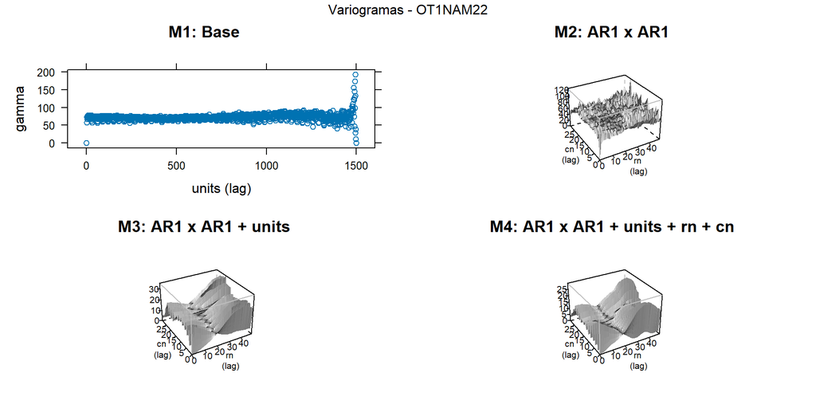

```r
gridExtra::grid.arrange(
  p1, p2, p3, p4,
  ncol = 2, nrow = 2,
  top = paste("Variogramas -", amb))
```

#### 5.6.2 Ambiente OT1RWE21

```r
amb = "OT1RWE21"

p5 = plot(varioGram(lista_modelos[[amb]]$M1), main = "M1: Base")
```

```r
p6 = plot(varioGram(lista_modelos[[amb]]$M2), main = "M2: AR1 x AR1")
```

```r
p7 = plot(varioGram(lista_modelos[[amb]]$M3), main = "M3: AR1 x AR1 + units")
```

```r
p8 = plot(varioGram(lista_modelos[[amb]]$M4), main = "M4: AR1 x AR1 + units + rn + cn")
```

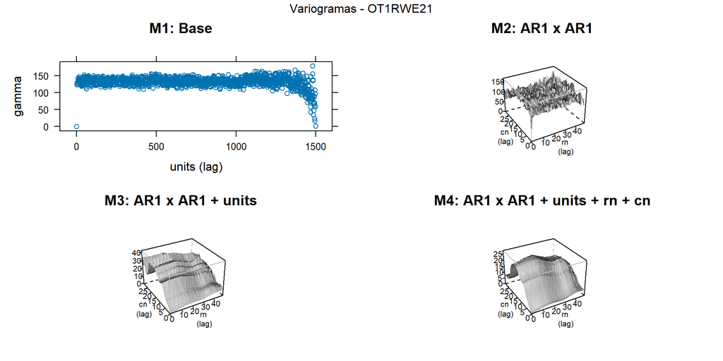

```r
gridExtra::grid.arrange(
  p5, p6, p7, p8,
  ncol = 2, nrow = 2,
  top = paste("Variogramas -", amb))
```

#### 5.6.3 Ambiente OT1RWE22

```r
amb = "OT1RWE22"

p9 = plot(varioGram(lista_modelos[[amb]]$M1), main = "M1: Base")
```

```r
p10 = plot(varioGram(lista_modelos[[amb]]$M2), main = "M2: AR1 x AR1")
```

```r
p11 = plot(varioGram(lista_modelos[[amb]]$M3), main = "M3: AR1 x AR1 + units")
```

```r
p12 = plot(varioGram(lista_modelos[[amb]]$M4), main = "M4: AR1 x AR1 + units + rn + cn")
```

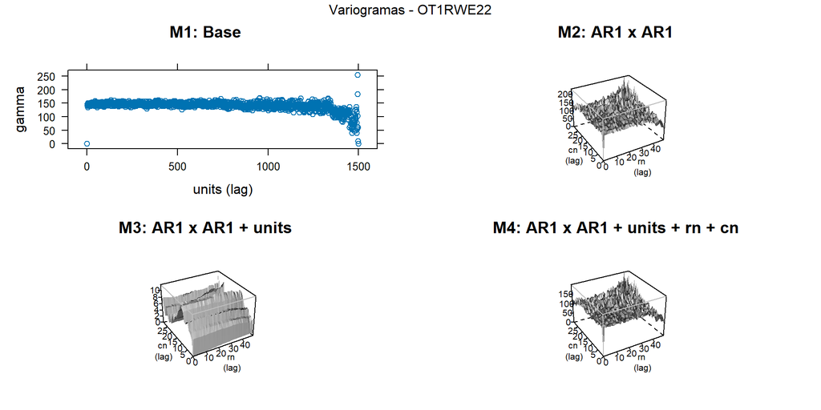

```r
gridExtra::grid.arrange(
  p9, p10, p11, p12,
  ncol = 2, nrow = 2,
  top = paste("Variogramas -", amb))
```

#### 5.6.4 Ambiente OT1SER22

```r
amb = "OT1SER22"

p13 = plot(varioGram(lista_modelos[[amb]]$M1), main = "M1: Base")
```

```r
p14 = plot(varioGram(lista_modelos[[amb]]$M2), main = "M2: AR1 x AR1")
```

```r
p15 = plot(varioGram(lista_modelos[[amb]]$M3), main = "M3: AR1 x AR1 + units")
```

```r
p16 = plot(varioGram(lista_modelos[[amb]]$M4), main = "M4: AR1 x AR1 + units + rn + cn")
```

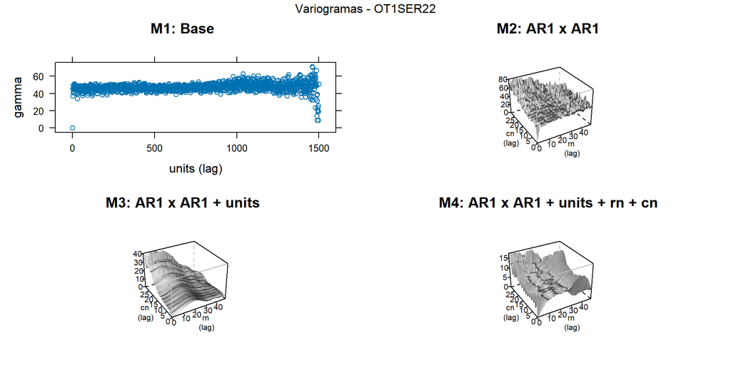

```r
gridExtra::grid.arrange(
  p13, p14, p15, p16,
  ncol = 2, nrow = 2,
  top = paste("Variogramas -", amb))
```

#### 5.6.5 Ambiente OT2NAM21

```r
amb = "OT2NAM21"

p17 = plot(varioGram(lista_modelos[[amb]]$M1), main = "M1: Base")
```

```r
p18 = plot(varioGram(lista_modelos[[amb]]$M2), main = "M2: AR1 x AR1")
```

```r
p19 = plot(varioGram(lista_modelos[[amb]]$M3), main = "M3: AR1 x AR1 + units")
```

```r
p20 = plot(varioGram(lista_modelos[[amb]]$M4), main = "M4: AR1 x AR1 + units + rn + cn")
```

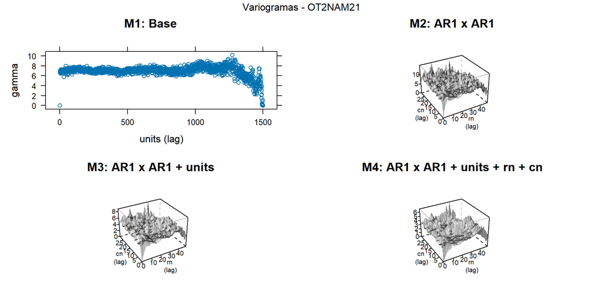

```r
gridExtra::grid.arrange(
  p17, p18, p19, p20,
  ncol = 2, nrow = 2,
  top = paste("Variogramas -", amb))
```

#### 5.6.6 Ambiente OT2SER21

```r
amb = "OT2SER21"

p21 = plot(varioGram(lista_modelos[[amb]]$M1), main = "M1: Base")
```

```r
p22 = plot(varioGram(lista_modelos[[amb]]$M2), main = "M2: AR1 x AR1")
```

```r
p23 = plot(varioGram(lista_modelos[[amb]]$M3), main = "M3: AR1 x AR1 + units")
```

```r
p24 = plot(varioGram(lista_modelos[[amb]]$M4), main = "M4: AR1 x AR1 + units + rn + cn")
```

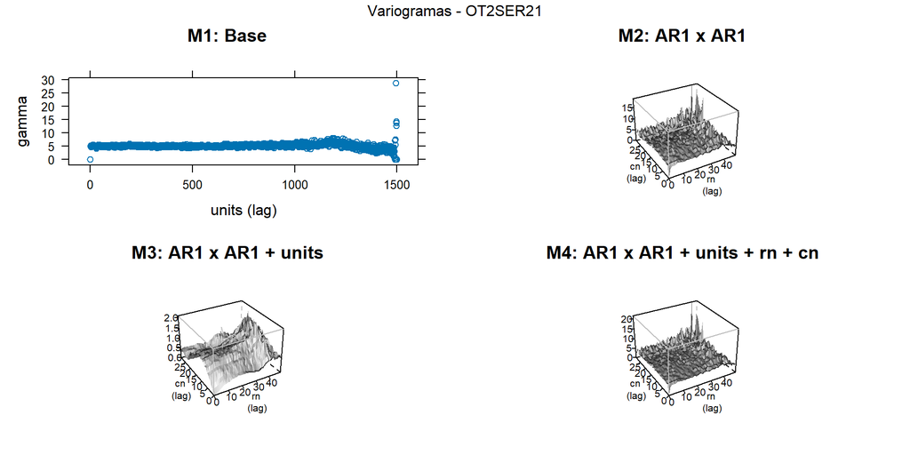

```r
gridExtra::grid.arrange(
  p21, p22, p23, p24,
  ncol = 2, nrow = 2,
  top = paste("Variogramas -", amb))
```

Os variogramas indicaram presença de estrutura espacial residual nos modelos sem ajuste espacial, representado por gráficos de pontos. Nos modelos espaciais, representados por superfícies 3D, a redução de picos, ondas e irregularidades indicou melhor controle da dependência espacial entre parcelas. De modo geral, os modelos espaciais apresentaram superfícies mais homogêneas e com menor variação residual em comparação ao modelo base, embora a intensidade dessa melhora tenha variado entre os ambientes.